# Notebook 03: Perform QC

Author

Shirshak Aryal

Published

July 3, 2026

Perform **Quality Control (QC) measures** on the **`unstranded` raw counts matrix**. This project focuses on **proneural and mesenchymal subtypes only**, and it is customary to analyze **only the coding genes** since **proteins** are the structural and functional components of any cell; they are literally what makes up the cell in the first place.

The QC steps therefore are applied to the **subset of only the coding genes of Proneural (PN) and Mesenchymal (ME) tumors**. Hence, the QC steps are:

- only **retain** the samples of the **Proneural (PN) and Mesenchymal (ME)** tumor subtypes
- only **retain protein-coding genes**

and then save the insights and outputs.

## 1. Import Libraries

```r
library(tidyverse)  # data manipulation and visualisation
library(patchwork)  # combine multiple ggplot2 plots into one canvas

cat("\nLibraries loaded successfully\n")
```

```
Libraries loaded successfully
```

```r
cat("tidyverse version:", as.character(packageVersion("tidyverse")), "\n")
```

```
tidyverse version: 2.0.0
```

```r
cat("patchwork version:", as.character(packageVersion("patchwork")), "\n")
```

```
patchwork version: 1.3.2
```

## 2. Load Data

### 2.1. Load Raw Counts Matrix

Load the `unstranded` raw counts matrix.

```r
raw_counts_matrix <- readRDS("../01_data/02_processed/01_raw_counts_matrix.rds")
cat("Raw counts matrix loaded:", nrow(raw_counts_matrix), "genes x", ncol(raw_counts_matrix), "samples\n")
```

```
Raw counts matrix loaded: 60660 genes x 372 samples
```

```r
cat("\n\nFirst few rows (genes) and columns (samples):\n\n")
```

```
First few rows (genes) and columns (samples):
```

```r
raw_counts_matrix[1:3, 1:3]
```

```
                   TCGA-06-6390-01A-11R-A96S-41 TCGA-06-5411-01A-01R-1849-01
ENSG00000000003.15                         2934                         2345
ENSG00000000005.6                            10                            9
ENSG00000000419.13                          762                         1843
                   TCGA-06-5411-01A-01R-A96S-41
ENSG00000000003.15                         1550
ENSG00000000005.6                             3
ENSG00000000419.13                         1180
```

### 2.2. Load Tumor Subtype Information

```r
tumor_subtype_info <- readRDS("../01_data/02_processed/02_tumor_subtype_info.rds")
cat("Tumor subtype info loaded:", nrow(tumor_subtype_info), "samples\n")
```

```
Tumor subtype info loaded: 372 samples
```

```r
cat("\n\nFirst few rows (samples) and columns (tumor subtype info):\n\n")
```

```
First few rows (samples) and columns (tumor subtype info):
```

```r
tumor_subtype_info[1:3, 1:5] %>% as.data.frame() %>% knitr::kable()
```

|  | barcode | patient | sample | shortLetterCode | definition |
| --- | --- | --- | --- | --- | --- |
| TCGA-06-6390-01A-11R-A96S-41 | TCGA-06-6390-01A-11R-A96S-41 | TCGA-06-6390 | TCGA-06-6390-01A | TP | Primary solid Tumor |
| TCGA-06-5411-01A-01R-1849-01 | TCGA-06-5411-01A-01R-1849-01 | TCGA-06-5411 | TCGA-06-5411-01A | TP | Primary solid Tumor |
| TCGA-06-5411-01A-01R-A96S-41 | TCGA-06-5411-01A-01R-A96S-41 | TCGA-06-5411 | TCGA-06-5411-01A | TP | Primary solid Tumor |

### 2.3. Load Gene Metadata

```r
gene_metadata <- readRDS("../01_data/02_processed/03_gene_metadata.rds")
cat("Gene metadata loaded:", nrow(gene_metadata), "genes\n")
```

```
Gene metadata loaded: 60660 genes
```

```r
cat("\n\nFirst few rows (genes) and columns (gene metadata):\n\n")
```

```
First few rows (genes) and columns (gene metadata):
```

```r
gene_metadata[1:5, 1:5] %>% as.data.frame() %>% knitr::kable()
```

|  | source | type | score | phase | gene_id |
| --- | --- | --- | --- | --- | --- |
| ENSG00000000003.15 | HAVANA | gene | NA | NA | ENSG00000000003.15 |
| ENSG00000000005.6 | HAVANA | gene | NA | NA | ENSG00000000005.6 |
| ENSG00000000419.13 | HAVANA | gene | NA | NA | ENSG00000000419.13 |
| ENSG00000000457.14 | HAVANA | gene | NA | NA | ENSG00000000457.14 |
| ENSG00000000460.17 | HAVANA | gene | NA | NA | ENSG00000000460.17 |

## 3. Visualise Pre-QC Data

These plots will serve as the basis of comparison with post-QC data plots to adjust/justify the filtering choices made below.

### 3.1. Create Individual Pre-QC Plots

#### 3.1.1. Plot Pre-QC Subtype Distribution

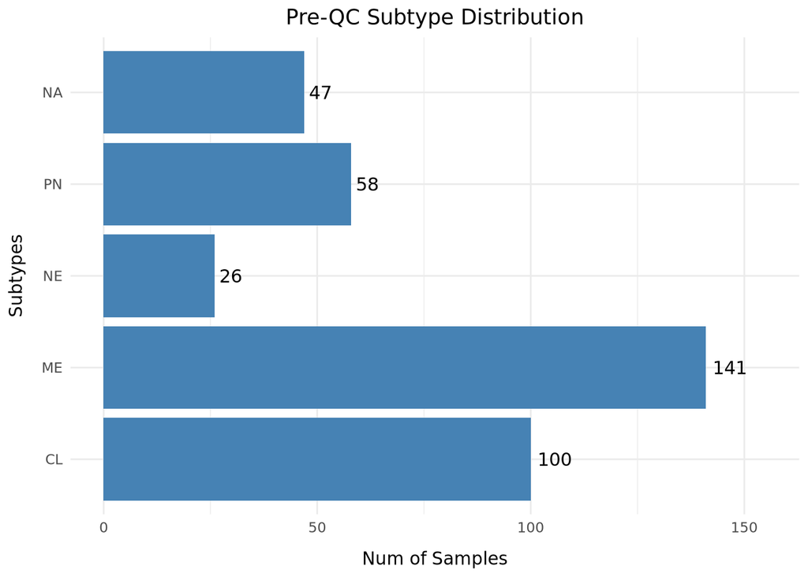

```r
#| fig-width: 5   # canvas width
#| fig-height: 5  # canvas height


# data source
pre_subtype_data <- as.data.frame(tumor_subtype_info) %>%  # data source
                    count(paper_Transcriptome.Subtype)     # freq of each subtype

# data to plot
# NOTE: plot is horizontal, hence x and y mappings are exchanged
pre_subtype_mapping <- aes(
                         y = paper_Transcriptome.Subtype,  # subtype names as y ticks
                         x = n                             # subtype frequency as x ticks
                       )

# plot color
pre_subtype_fill <- "steelblue"

# plot labels
pre_subtype_labels <- labs(
                        title = "Pre-QC Subtype Distribution",  # plot title
                        y = "Subtypes",                         # y-axis label
                        x = "Num of Samples"                    # x-axis label
                      )

# create plot
pre_subtype_plot <- ggplot(pre_subtype_data, pre_subtype_mapping) +          # data

                    geom_bar(                                                # plot bar graph
                      stat = "identity",                                     # use the 'n' calculated above instead of re-counting the num of rows as done normally
                      fill = pre_subtype_fill                                # bar color
                    ) +

                    geom_text(
                      aes(label = n),                                        # display the count value
                      hjust = -0.2,                                          # nudge label just outside the bar end
                      size = 4
                    ) +
                    xlim(0, max(pre_subtype_data$n) * 1.1) +                 # expand x axis slightly so label isn't clipped

                    pre_subtype_labels +                                     # labels

                    theme_minimal() +                                        # color theme
                    theme(
                      plot.title = element_text(hjust = 0.5),                # center the title
                      axis.title.x = element_text(margin = margin(t = 10)),  # add top margin to x-axis label
                      axis.title.y = element_text(margin = margin(r = 10))   # add right margin to y-axis label
                    )

# show plot
pre_subtype_plot
```

#### 3.1.2. Plot Pre-QC Gene Biotype Distribution

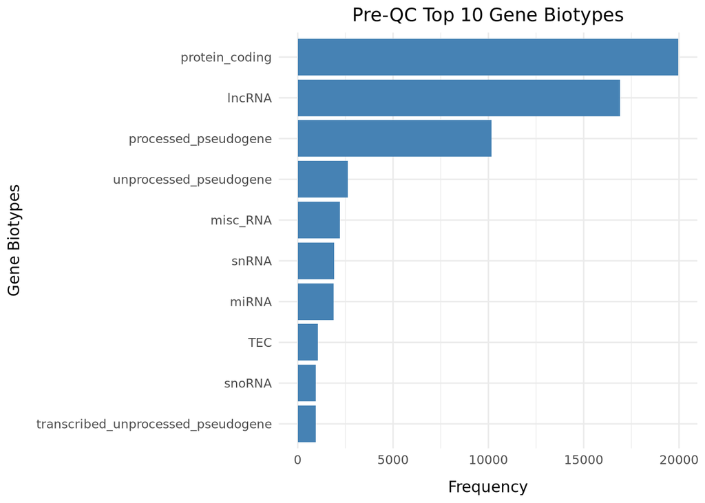

```r
#| fig-width: 5   # canvas width
#| fig-height: 5  # canvas height


# data source
pre_biotype_data <- gene_metadata %>%     # data source
                    count(gene_type) %>%  # count num of each biotype
                    arrange(desc(n)) %>%  # descending order
                    slice_head(n = 10)    # show only top 10

# data to plot
# NOTE: plot is horizontal, hence x and y mappings are exchanged
pre_biotype_mapping <- aes(
                         y = reorder(gene_type, n),  # biotype names as y ticks
                         x = n                       # biotype frequency as x ticks
                       )

# plot color
pre_biotype_fill    <- "steelblue"

# plot labels
pre_biotype_labels  <- labs(
                         title = "Pre-QC Top 10 Gene Biotypes",  # plot title
                         y = "Gene Biotypes",                    # y-axis label
                         x = "Frequency"                         # x-axis label
                       )

# create plot
pre_biotype_plot <- ggplot(pre_biotype_data, pre_biotype_mapping) +          # data

                    geom_bar(                                                # plot bar graph
                      stat = "identity",                                     # use the 'n' calculated above instead of re-counting the num of rows as done normally
                      fill = pre_biotype_fill                                # bar color
                    ) +

                    pre_biotype_labels +                                     # labels

                    theme_minimal() +                                        # color theme
                    theme(
                      plot.title = element_text(hjust = 0.5),                # center the title
                      axis.title.x = element_text(margin = margin(t = 10)),  # add top margin to x-axis label
                      axis.title.y = element_text(margin = margin(r = 10))   # add right margin to y-axis label
                    )

# show plot
pre_biotype_plot
```

#### 3.1.3. Plot Pre-QC Library Size Distribution

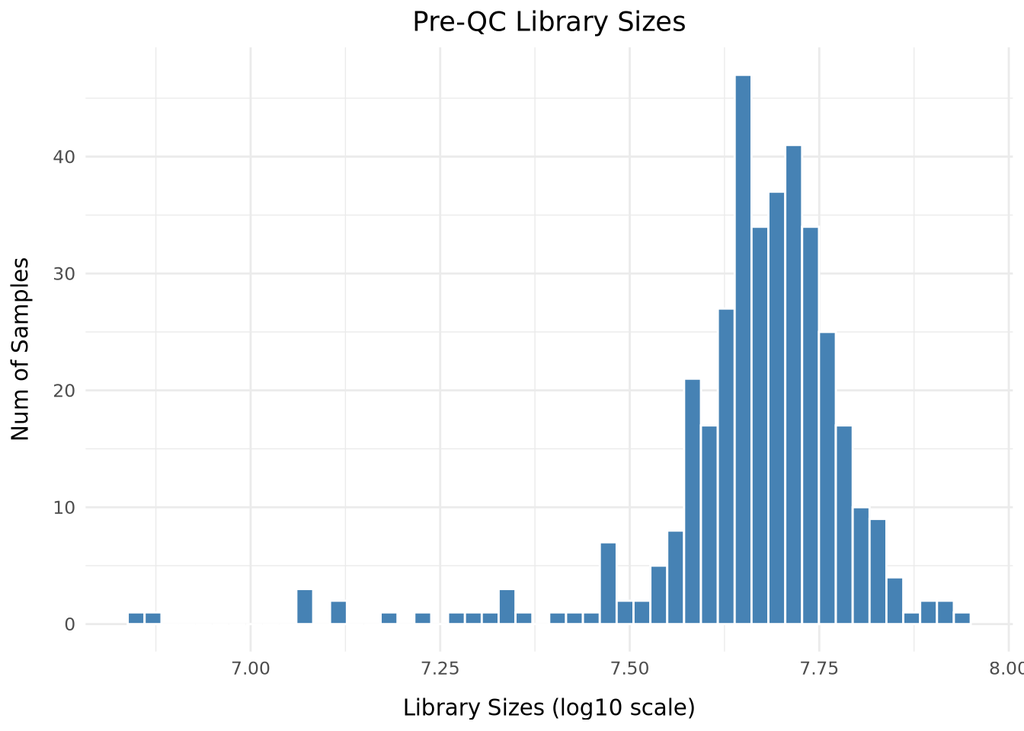

```r
#| fig-width: 5   # canvas width
#| fig-height: 5  # canvas height


# create dataframe with log10 library sizes as a column
pre_libsize_data    <- data.frame(
                         lib_size = log10(colSums(raw_counts_matrix))
                       )

# map lib_size column to x axis
pre_libsize_mapping <- aes(x = lib_size)

# plot color
pre_libsize_fill    <- "steelblue"

# plot labels
pre_libsize_labels  <- labs(
                         title = "Pre-QC Library Sizes",     # plot title
                         x = "Library Sizes (log10 scale)",  # x-axis label
                         y = "Num of Samples"                # y-axis label
                       )

# create plot
pre_libsize_plot <- ggplot(pre_libsize_data, pre_libsize_mapping) +          # data

                    geom_histogram(                                          # plot histogram
                      bins = 50,                                             # num of bins
                      fill = pre_libsize_fill,                               # bin color
                      colour = "white"                                       # bin outline
                    ) +

                    pre_libsize_labels +                                     # labels

                    theme_minimal() +                                        # color theme
                    theme(
                      plot.title = element_text(hjust = 0.5),                # center the title
                      axis.title.x = element_text(margin = margin(t = 10)),  # add top margin to x-axis label
                      axis.title.y = element_text(margin = margin(r = 10))   # add right margin to y-axis label
                    )

# show plot
pre_libsize_plot
```

#### 3.1.4. Plot Pre-QC Genes Detected Per Sample

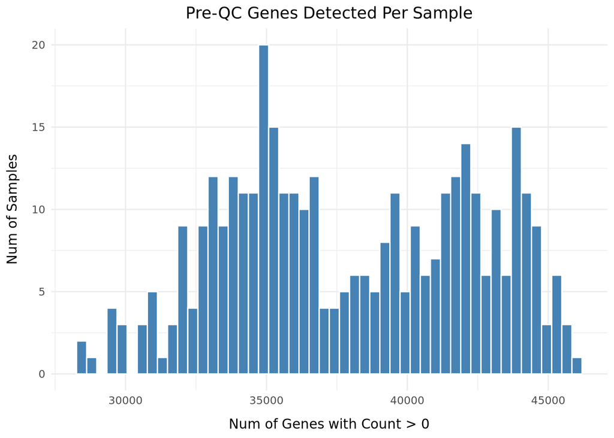

```r
#| fig-width: 5   # canvas width
#| fig-height: 5  # canvas height


# create dataframe with per-sample num of genes with counts > 0 as a column
pre_genedet_data    <- data.frame(genes_detected = colSums(raw_counts_matrix > 0))

# map genes_detected column to x axis
pre_genedet_mapping <- aes(x = genes_detected)

# plot color
pre_genedet_fill    <- "steelblue"

# plot labels
pre_genedet_labels  <- labs(
                         title = "Pre-QC Genes Detected Per Sample",  # plot title
                         x = "Num of Genes with Count > 0",           # x-axis label
                         y = "Num of Samples"                         # y-axis label
                       )

# create plot
pre_genedet_plot <- ggplot(pre_genedet_data, pre_genedet_mapping) +  # data

                    geom_histogram(                                  # plot histogram
                      bins = 50,                                     # num of bins
                      fill = pre_genedet_fill,                       # bin color
                      colour = "white"                               # bin outline
                    ) +

                    pre_genedet_labels +                             # labels

                    theme_minimal() +                                # color theme
                    theme(
                      # center the title
                      plot.title = element_text(hjust = 0.5),

                      # add top margin to x-axis label
                      axis.title.x = element_text(margin = margin(t = 10)),

                      # add right margin to y-axis label
                      axis.title.y = element_text(margin = margin(r = 10))
                    )

# show plot
pre_genedet_plot
```

#### 3.1.5. Plot Pre-QC Expression Density

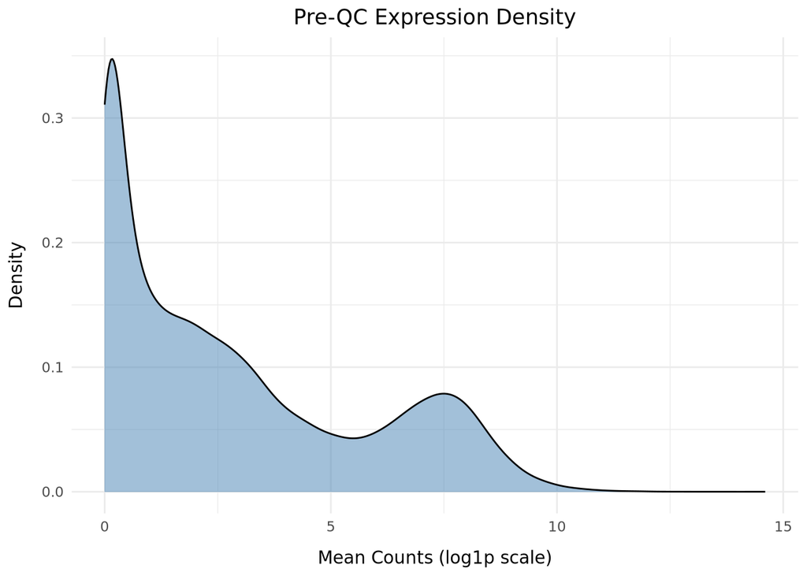

```r
#| fig-width: 5   # canvas width
#| fig-height: 5  # canvas height


# create dataframe with mean gene expressions as a column
pre_exprdens_data    <- data.frame(mean_expr = log1p(rowMeans(raw_counts_matrix)))

# map mean_expr column to x axis
pre_exprdens_mapping <- aes(x = mean_expr)

# plot color
pre_exprdens_fill    <- "steelblue"

# plot labels
pre_exprdens_labels  <- labs(
                         title = "Pre-QC Expression Density",       # plot title
                         x = "Mean Counts (log1p scale)",           # x-axis label
                         y = "Density"                              # y-axis label
                       )

# create plot
pre_exprdens_plot <- ggplot(pre_exprdens_data, pre_exprdens_mapping) +  # data

                     geom_density(                                      # density plot
                       fill = pre_exprdens_fill,                        # line color
                       alpha = 0.5                                      # opacity
                     ) +

                     pre_exprdens_labels +                              # labels

                     theme_minimal() +                                  # color theme
                     theme(
                      # center the title
                      plot.title = element_text(hjust = 0.5),

                      # add top margin to x-axis label
                      axis.title.x = element_text(margin = margin(t = 10)),

                      # add right margin to y-axis label
                      axis.title.y = element_text(margin = margin(r = 10))
                    )

# show plot
pre_exprdens_plot
```

### 3.2. Create Combined Pre-QC Plots

#### 3.2.1. Combine Sample-Level Pre-QC Plots

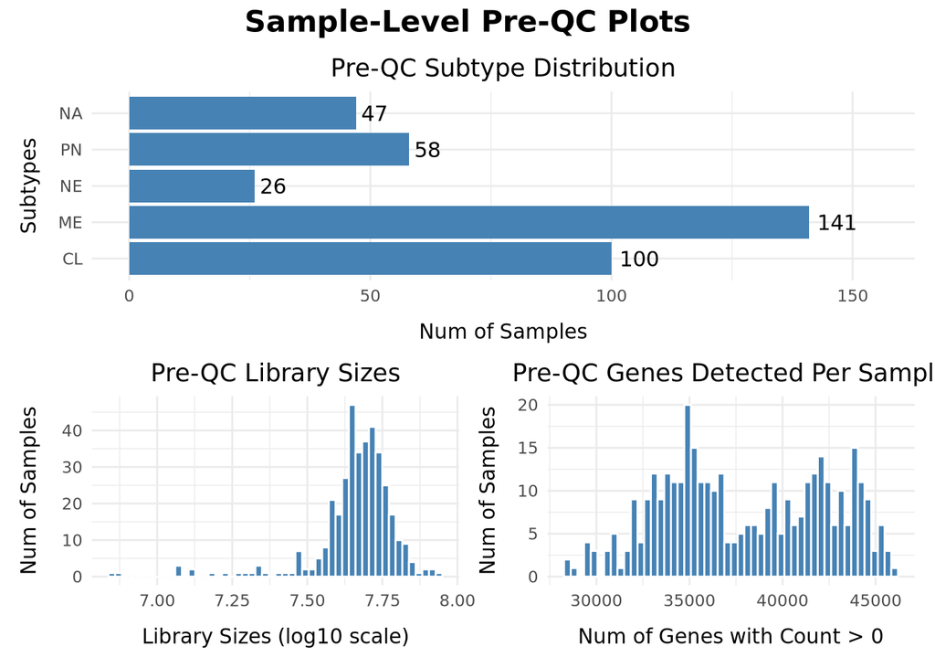

```r
#| fig-width: 10   # canvas width
#| fig-height: 15  # canvas height


sample_level_pre_qc_plots <-
(pre_subtype_plot) /
(pre_libsize_plot | pre_genedet_plot) +
plot_annotation(
  title = "Sample-Level Pre-QC Plots",
  theme = theme(
            plot.title = element_text(
              hjust = 0.5,
              size = 16,
              face = "bold"
            )
          )
)

sample_level_pre_qc_plots
```

#### 3.2.2. Combine Gene-Level Pre-QC Plots

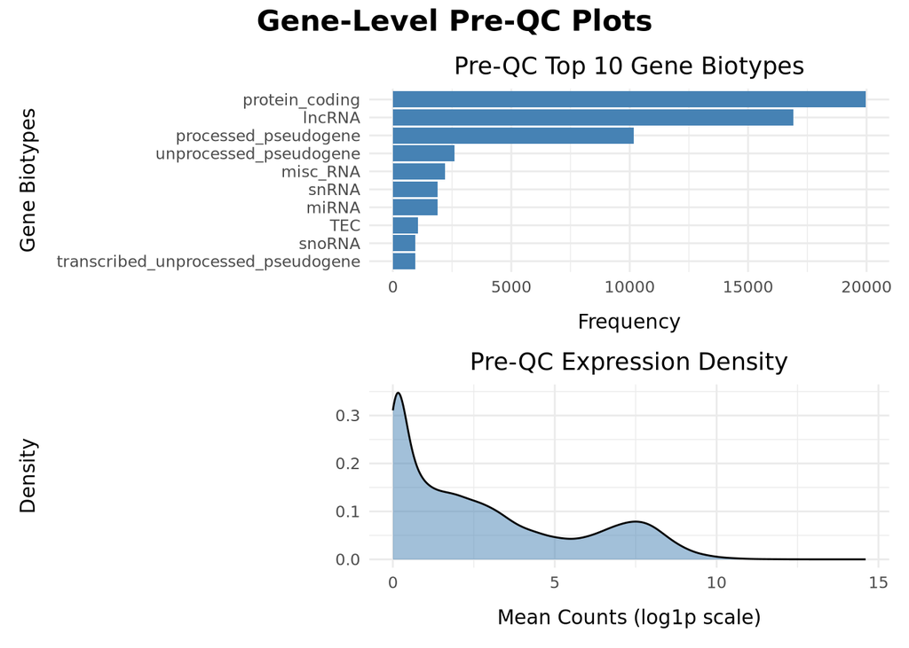

```r
#| fig-width: 10   # canvas width
#| fig-height: 15  # canvas height


gene_level_pre_qc_plots <-
(pre_biotype_plot) /
(pre_exprdens_plot) +
plot_annotation(
  title = "Gene-Level Pre-QC Plots",
  theme = theme(
            plot.title = element_text(
              hjust = 0.5,
              size = 16,
              face = "bold"
            )
          )
)

gene_level_pre_qc_plots
```

## 4. Perform QC

### 4.1. Filter to Proneural and Mesenchymal Samples

#### 4.1.1. Inspect Subtype Names In Tumor Subtype Information

```r
cat("GBM tumor subtype names:\n")
```

```
GBM tumor subtype names:
```

```r
tumor_subtype_info %>%
  as.data.frame() %>%                      # use as dataframe
  select(paper_Transcriptome.Subtype) %>%  # select Subtype column only
  head(10) %>%                             # select first 10 rows only
  knitr::kable()                           # show table
```

|  | paper_Transcriptome.Subtype |
| --- | --- |
| TCGA-06-6390-01A-11R-A96S-41 | CL |
| TCGA-06-5411-01A-01R-1849-01 | NE |
| TCGA-06-5411-01A-01R-A96S-41 | NE |
| TCGA-12-3648-01A-01R-A96T-41 | CL |
| TCGA-06-A7TK-01A-21R-A96S-41 | NA |
| TCGA-19-5959-01A-11R-A96U-41 | CL |
| TCGA-06-0166-01A-01R-A96R-41 | PN |
| TCGA-06-5859-01A-01R-1849-01 | ME |
| TCGA-06-5859-01A-01R-A96S-41 | ME |
| TCGA-14-4157-01A-01R-A96U-41 | PN |

#### 4.1.2. Filter to Proneural and Mesenchymal Samples

```r
# get sample IDs matching PN or ME subtypes
pn_me_samples <- rownames(tumor_subtype_info)[
  tumor_subtype_info$paper_Transcriptome.Subtype %in% c("PN", "ME")
]

# subset raw counts matrix and tumor subtype info file using the selected sample IDs
raw_counts_matrix      <- raw_counts_matrix[, pn_me_samples]
tumor_subtype_info     <- tumor_subtype_info[pn_me_samples, ]

cat("Samples retained by subtype:\n")
```

```
Samples retained by subtype:
```

```r
print(table(tumor_subtype_info$paper_Transcriptome.Subtype))
```

```
 CL  ME  NE  PN
  0 141   0  58
```

```r
cat("\nTotal samples after filter:", ncol(raw_counts_matrix), "\n")
```

```
Total samples after filter: 199
```

### 4.2. Filter to Protein Coding Genes

```r
# get gene IDs matching protein_coding biotype
protein_coding_ids <- rownames(gene_metadata)[
  gene_metadata$gene_type == "protein_coding"
]

# subset raw counts matrix and gene metadata file using the selected gene IDs
raw_counts_matrix <- raw_counts_matrix[
  rownames(raw_counts_matrix) %in% protein_coding_ids,
]
gene_metadata <- gene_metadata[gene_metadata$gene_type == "protein_coding", ]

cat("Total genes after filter:", nrow(raw_counts_matrix), "\n")
```

```
Total genes after filter: 19962
```

### 4.3. QC Genes: Filter Lowly Expressed Genes

Genes are **retained** only if they have **counts at least CPM > 1 (industry standard)** and **in at least 20% of the smaller group size** **(reasonable, dataset-specific threshold)**. In this case, that is **20% of the 58 Proneural samples, i.e. ~12 samples.**

#### 4.3.1. CPM Normalize Raw Counts Matrix

```r
cpm_matrix <- sweep(
                raw_counts_matrix,                 # take raw counts matrix
                2,                                 # go thru cols (instead of rows)
                colSums(raw_counts_matrix) / 1e6,  # scaling factor
                FUN = "/"                          # divide all values by their column-specific scaling factor (hence the '2' specified above)
              )

cat("CPM matrix dimensions:", nrow(cpm_matrix), "genes x", ncol(cpm_matrix), "samples\n")
```

```
CPM matrix dimensions: 19962 genes x 199 samples
```

```r
cat("\n\nFirst few rows (genes) and columns (samples):\n\n")
```

```
First few rows (genes) and columns (samples):
```

```r
cpm_matrix[1:3, 1:3]  # show row 1 to 3, column 1 to 3
```

```
                   TCGA-06-0166-01A-01R-A96R-41 TCGA-06-5859-01A-01R-1849-01
ENSG00000000003.15                   40.3456933                   119.438558
ENSG00000000005.6                     0.1314192                     2.374981
ENSG00000000419.13                   17.7415915                    28.557231
                   TCGA-06-5859-01A-01R-A96S-41
ENSG00000000003.15                   112.466703
ENSG00000000005.6                      2.742598
ENSG00000000419.13                    25.227873
```

#### 4.3.2. Filter Lowly Expressed Genes

```r
# Threshold: CPM > 1 in at least 20% of Proneural samples (smaller group)
# The % is iteratively adjusted according to post-QC details
n_proneural  <- sum(tumor_subtype_info$paper_Transcriptome.Subtype == "PN")
min_samples  <- ceiling(0.20 * n_proneural)

keep_genes        <- rowSums(cpm_matrix > 1) >= min_samples
raw_counts_matrix <- raw_counts_matrix[keep_genes, ]
gene_metadata <- gene_metadata[rownames(gene_metadata) %in% rownames(raw_counts_matrix), ]

cat("Proneural sample count (smaller group):", n_proneural, "\n")
```

```
Proneural sample count (smaller group): 58
```

```r
cat("Min samples threshold (20%):", min_samples, "\n")
```

```
Min samples threshold (20%): 12
```

```r
cat("Genes after expression filter:", nrow(raw_counts_matrix), "\n")
```

```
Genes after expression filter: 16164
```

```r
cat("\n\nFirst few rows (genes) and columns (samples) after filter:\n\n")
```

```
First few rows (genes) and columns (samples) after filter:
```

```r
raw_counts_matrix[1:3, 1:3]  # show row 1 to 3, column 1 to 3
```

```
                   TCGA-06-0166-01A-01R-A96R-41 TCGA-06-5859-01A-01R-1849-01
ENSG00000000003.15                         2149                         6236
ENSG00000000005.6                             7                          124
ENSG00000000419.13                          945                         1491
                   TCGA-06-5859-01A-01R-A96S-41
ENSG00000000003.15                         5577
ENSG00000000005.6                           136
ENSG00000000419.13                         1251
```

### 4.4. QC Samples

#### 4.4.1. Filter Samples With Low Library Sizes

##### 4.4.1.1. Assess Sample Library Sizes

```r
# Median Absolute Deviation (MAD)-based threshold
log10_lib_sizes  <- log10(colSums(raw_counts_matrix))  # log10 transform library sizes
lib_sizes_median <- median(log10_lib_sizes)            # calculate median library size
lib_sizes_mad    <- mad(log10_lib_sizes)               # calculate MAD


# libraries BELOW (not above) 3 MADs are outliers
# iteratively adjusted according to post-QC details
lib_sizes_outlier_flags <- log10_lib_sizes < (lib_sizes_median - 3 * lib_sizes_mad)

cat("Library size assessment (log10 scale):\n")
```

```
Library size assessment (log10 scale):
```

```r
cat("\nMedian:", round(lib_sizes_median, 3), "\n")
```

```
Median: 7.639
```

```r
cat("MAD:   ", round(lib_sizes_mad, 3), "\n")
```

```
MAD:    0.102
```

```r
cat("\nOutliers flagged (> 3 MADs below median):", sum(lib_sizes_outlier_flags), "\n")
```

```
Outliers flagged (> 3 MADs below median): 11
```

```r
if (any(lib_sizes_outlier_flags)) {
  cat("Outlier samples:\n")
  print(names(lib_sizes_outlier_flags)[lib_sizes_outlier_flags])
}
```

```
Outlier samples:
 [1] "TCGA-26-5136-01B-01R-1850-01" "TCGA-28-5213-01A-01R-1850-01"
 [3] "TCGA-06-0878-01A-01R-1849-01" "TCGA-06-0139-01A-01R-1849-01"
 [5] "TCGA-32-4213-01A-01R-1850-01" "TCGA-06-0138-01A-01R-A96R-41"
 [7] "TCGA-06-0168-01A-01R-1849-01" "TCGA-32-1982-01A-01R-1850-01"
 [9] "TCGA-28-1753-01A-01R-1850-01" "TCGA-14-1825-01A-01R-1850-01"
[11] "TCGA-12-3644-01A-01R-A96T-41"
```

##### 4.4.1.2. Remove Low Library Size Outlier Samples

```r
# Subset raw counts matrix and tumor subtype info file to non-outlier samples
raw_counts_matrix  <- raw_counts_matrix[, !lib_sizes_outlier_flags]
tumor_subtype_info <- tumor_subtype_info[!lib_sizes_outlier_flags, ]

cat("Samples removed:", sum(lib_sizes_outlier_flags), "\n")
```

```
Samples removed: 11
```

```r
cat("Samples remaining:", ncol(raw_counts_matrix), "\n")
```

```
Samples remaining: 188
```

```r
cat("\n\nSubtype distribution after removal:\n")
```

```
Subtype distribution after removal:
```

```r
print(table(tumor_subtype_info$paper_Transcriptome.Subtype))
```

```
 CL  ME  NE  PN
  0 132   0  56
```

#### 4.4.2. Filter Samples With Low Gene Detection

Samples where very few genes have any counts at all are removed entirely.

##### 4.4.2.1. Assess Gene Detection

```r
# Median Absolute Deviation (MAD)-based threshold
num_genes_det        <- colSums(raw_counts_matrix > 0)  # num of genes with counts > 0
num_genes_det_median <- median(num_genes_det)           # calculate median
num_genes_det_MAD    <- mad(num_genes_det)              # calculate MAD


# samples BELOW (not above) 3 MADs are outliers
# iteratively adjusted according to post-QC details
genes_det_outlier_flags <- num_genes_det < (num_genes_det_median - 3 * num_genes_det_MAD)

cat("Gene detection assessment:\n")
```

```
Gene detection assessment:
```

```r
cat("Median genes detected:", round(num_genes_det_median), "\n")
```

```
Median genes detected: 16090
```

```r
cat("MAD:                  ", round(num_genes_det_MAD), "\n")
```

```
MAD:                   50
```

```r
cat("\nOutliers flagged (> 3 MADs below median):", sum(genes_det_outlier_flags), "\n")
```

```
Outliers flagged (> 3 MADs below median): 8
```

```r
if (any(genes_det_outlier_flags)) {
  cat("Outlier samples:\n")
  print(names(genes_det_outlier_flags)[genes_det_outlier_flags])
}
```

```
Outlier samples:
[1] "TCGA-06-0197-01A-02R-A96R-41" "TCGA-14-1034-01A-01R-1849-01"
[3] "TCGA-12-5301-01A-01R-A96T-41" "TCGA-06-0152-01A-02R-A96R-41"
[5] "TCGA-12-5295-01A-01R-A96T-41" "TCGA-12-5295-01A-01R-1849-01"
[7] "TCGA-06-0644-01A-02R-A96R-41" "TCGA-27-1831-01A-01R-1850-01"
```

##### 4.4.2.2. Remove Low Gene Detection Outlier Samples

```r
raw_counts_matrix  <- raw_counts_matrix[, !genes_det_outlier_flags]
tumor_subtype_info <- tumor_subtype_info[!genes_det_outlier_flags, ]

cat("Samples removed:", sum(genes_det_outlier_flags), "\n")
```

```
Samples removed: 8
```

```r
cat("Samples remaining:", ncol(raw_counts_matrix), "\n")
```

```
Samples remaining: 180
```

```r
cat("\n\nSubtype distribution after removal:\n")
```

```
Subtype distribution after removal:
```

```r
print(table(tumor_subtype_info$paper_Transcriptome.Subtype))
```

```
 CL  ME  NE  PN
  0 125   0  55
```

## 5. Visualise Post-QC Data

These plots will serve as the basis of comparison with pre-QC data plots to adjust/justify the filtering choices made above.

### 5.1. Create Individual Post-QC Plots

#### 5.1.1. Plot Post-QC Subtype Distribution

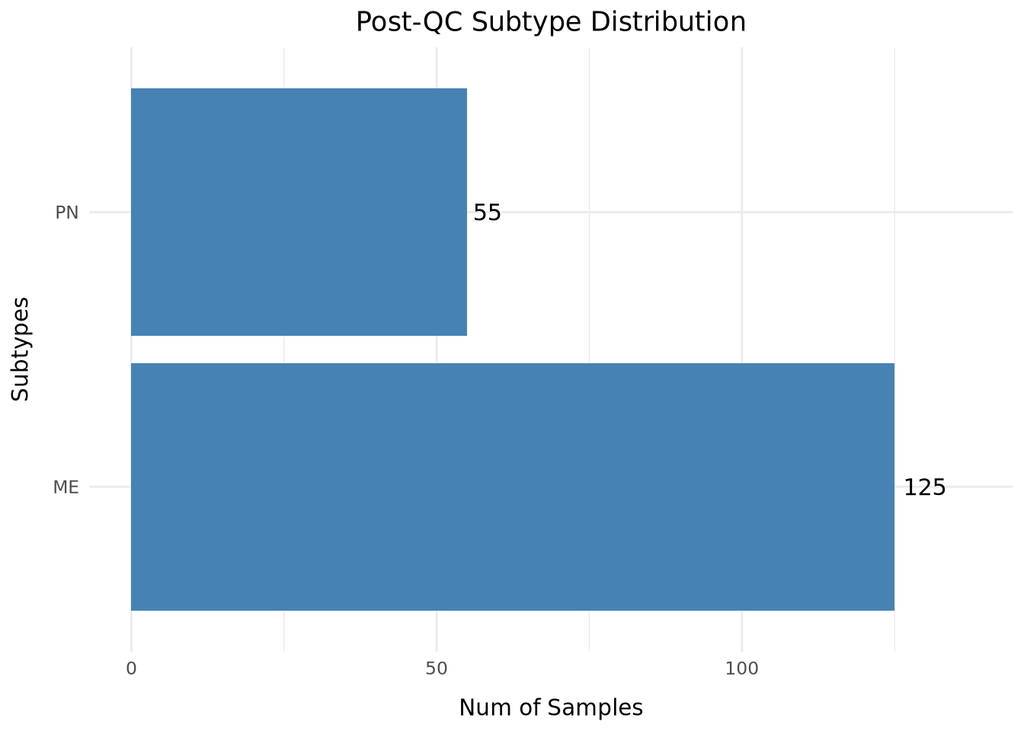

```r
#| fig-width: 5   # canvas width
#| fig-height: 5  # canvas height


# data source
post_subtype_data <- tumor_subtype_info %>%              # data source
                     count(paper_Transcriptome.Subtype)  # freq of each subtype

# data to plot
# NOTE: plot is horizontal, hence x and y mappings are exchanged
post_subtype_mapping <- aes(
                          # subtype names as y ticks
                          y = paper_Transcriptome.Subtype,

                          # subtype frequency as x ticks
                          x = n
                        )

# plot color
post_subtype_fill <- "steelblue"

# plot labels
post_subtype_labels <- labs(
                         title = "Post-QC Subtype Distribution",  # plot title
                         y = "Subtypes",                          # y-axis label
                         x = "Num of Samples"                     # x-axis label
                       )

# create plot
post_subtype_plot <- ggplot(post_subtype_data, post_subtype_mapping) +       # data

                    geom_bar(                                                # bar graph
                      stat = "identity",                                     # use the 'n' calculated above instead of re-counting the num of rows as done normally
                      fill = post_subtype_fill                               # bar color
                    ) +

                    geom_text(
                      aes(label = n),                                        # display the count value
                      hjust = -0.2,                                          # nudge label just outside the bar end
                      size = 4
                    ) +
                    xlim(0, max(post_subtype_data$n) * 1.1) +                # expand x axis slightly so label isn't clipped

                    post_subtype_labels +                                    # labels

                    theme_minimal() +                                        # color theme
                    theme(
                      plot.title = element_text(hjust = 0.5),                # center the title
                      axis.title.x = element_text(margin = margin(t = 10)),  # add top margin to x-axis label
                      axis.title.y = element_text(margin = margin(r = 10))   # add right margin to y-axis label
                    )

# show plot
post_subtype_plot
```

#### 5.1.2. Plot Post-QC Gene Biotype Distribution

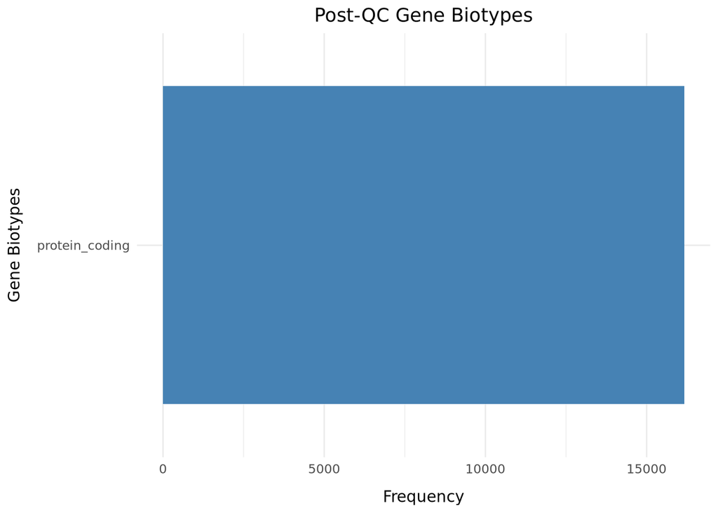

```r
#| fig-width: 5   # canvas width
#| fig-height: 5  # canvas height


# data source
post_biotype_data <- gene_metadata %>%     # data source
                     count(gene_type) %>%  # count num of each biotype
                     arrange(desc(n)) %>%  # descending order
                     slice_head(n = 10)    # show only top 10

# data to plot
# NOTE: plot is horizontal, hence x and y mappings are exchanged
post_biotype_mapping <- aes(
                         y = reorder(gene_type, n),  # biotype names as y ticks
                         x = n                       # biotype frequency as x ticks
                       )

# plot color
post_biotype_fill    <- "steelblue"

# plot labels
post_biotype_labels  <- labs(
                         title = "Post-QC Gene Biotypes",  # plot title
                         y = "Gene Biotypes",              # y-axis label
                         x = "Frequency"                   # x-axis label
                       )

# create plot
post_biotype_plot <- ggplot(post_biotype_data, post_biotype_mapping) +       # data

                    geom_bar(                                                # bar graph
                      stat = "identity",                                     # use the 'n' calculated above instead of re-counting the num of rows as done normally
                      fill = post_biotype_fill                               # bar color
                    ) +

                    post_biotype_labels +                                    # labels

                    theme_minimal() +                                        # color theme
                    theme(
                      plot.title = element_text(hjust = 0.5),                # center the title
                      axis.title.x = element_text(margin = margin(t = 10)),  # add top margin to x-axis label
                      axis.title.y = element_text(margin = margin(r = 10))   # add right margin to y-axis label
                    )

# show plot
post_biotype_plot
```

#### 5.1.3. Plot Post-QC Library Size Distribution

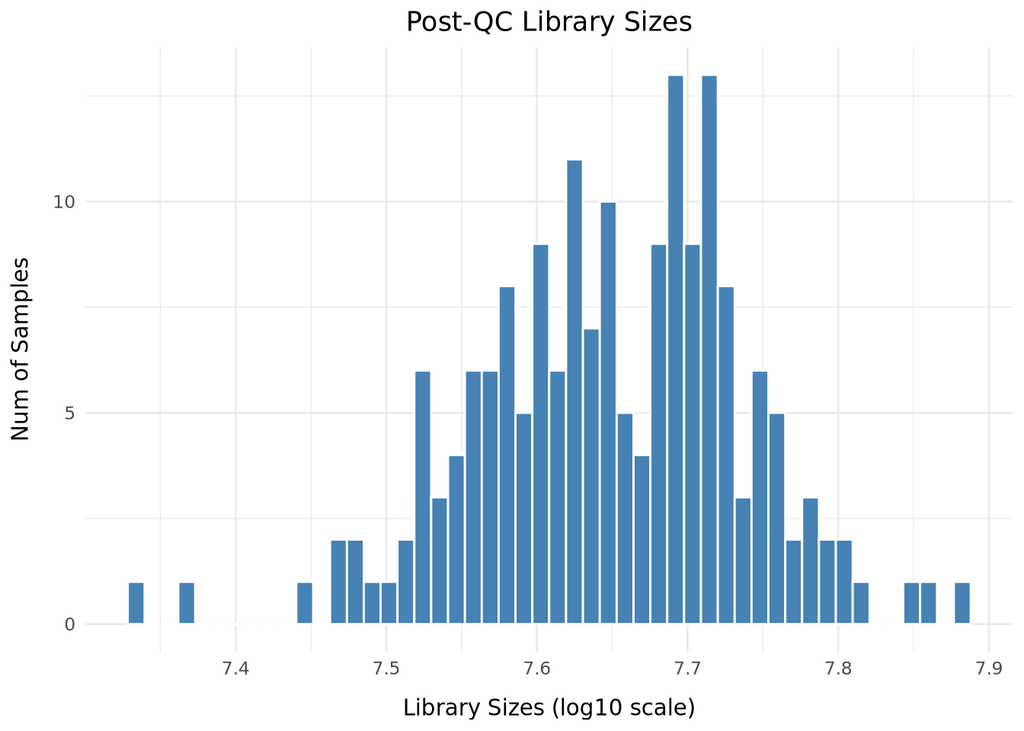

```r
#| fig-width: 5   # canvas width
#| fig-height: 5  # canvas height


# create dataframe with log10 library sizes as a column
post_libsize_data    <- data.frame(
                         lib_size = log10(colSums(raw_counts_matrix))
                       )

# map lib_size column to x axis
post_libsize_mapping <- aes(x = lib_size)

# plot color
post_libsize_fill    <- "steelblue"

# plot labels
post_libsize_labels  <- labs(
                         title = "Post-QC Library Sizes",     # plot title
                         x = "Library Sizes (log10 scale)",   # x-axis label
                         y = "Num of Samples"                 # y-axis label
                       )

# create plot
post_libsize_plot <- ggplot(post_libsize_data, post_libsize_mapping) +       # data

                    geom_histogram(                                          # histogram
                      bins = 50,                                             # num of bins
                      fill = post_libsize_fill,                              # bin color
                      colour = "white"                                       # bin outline
                    ) +

                    post_libsize_labels +                                    # labels

                    theme_minimal() +                                        # color theme
                    theme(
                      plot.title = element_text(hjust = 0.5),                # center the title
                      axis.title.x = element_text(margin = margin(t = 10)),  # add top margin to x-axis label
                      axis.title.y = element_text(margin = margin(r = 10))   # add right margin to y-axis label
                    )

# show plot
post_libsize_plot
```

#### 5.1.4. Plot Post-QC Genes Detected Per Sample

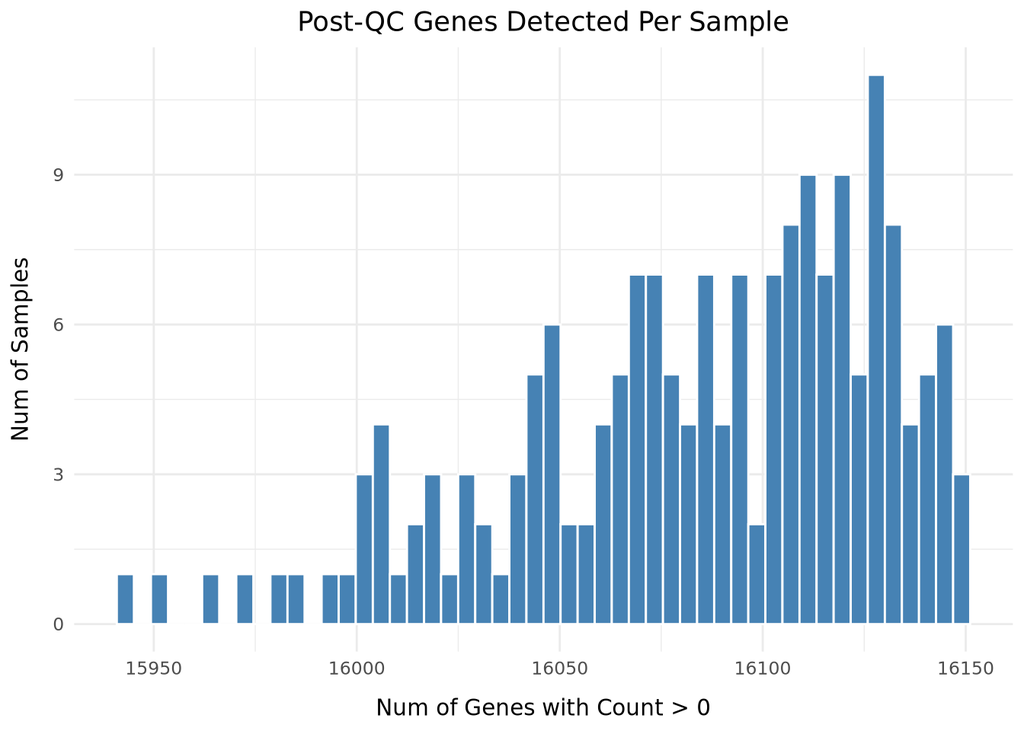

```r
#| fig-width: 5   # canvas width
#| fig-height: 5  # canvas height


# create dataframe with per-sample num of genes with counts > 0 as a column
post_genedet_data    <- data.frame(genes_detected = colSums(raw_counts_matrix > 0))

# map genes_detected column to x axis
post_genedet_mapping <- aes(x = genes_detected)

# plot color
post_genedet_fill    <- "steelblue"

# plot labels
post_genedet_labels  <- labs(
                         title = "Post-QC Genes Detected Per Sample",  # plot title
                         x = "Num of Genes with Count > 0",            # x-axis label
                         y = "Num of Samples"                          # y-axis label
                       )

# create plot
post_genedet_plot <- ggplot(post_genedet_data, post_genedet_mapping) +       # data
                    geom_histogram(                                          # histogram
                      bins = 50,                                             # num of bins
                      fill = post_genedet_fill,                              # bin color
                      colour = "white"                                       # bin outline
                    ) +
                    post_genedet_labels +                                    # labels
                    theme_minimal() +                                        # color theme
                    theme(
                      plot.title = element_text(hjust = 0.5),                # center the title
                      axis.title.x = element_text(margin = margin(t = 10)),  # add top margin to x-axis label
                      axis.title.y = element_text(margin = margin(r = 10))   # add right margin to y-axis label
                    )

# show plot
post_genedet_plot
```

#### 5.1.5. Plot Post-QC Expression Density

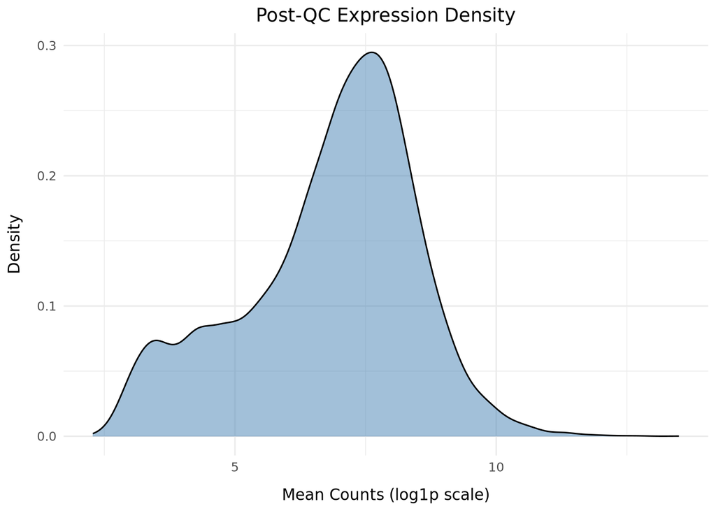

```r
#| fig-width: 5   # canvas width
#| fig-height: 5  # canvas height


# create dataframe with mean gene expressions as a column
post_exprdens_data    <- data.frame(mean_expr = log1p(rowMeans(raw_counts_matrix)))

# map mean_expr column to x axis
post_exprdens_mapping <- aes(x = mean_expr)

# plot color
post_exprdens_fill    <- "steelblue"

# plot labels
post_exprdens_labels  <- labs(
                         title = "Post-QC Expression Density",       # plot title
                         x = "Mean Counts (log1p scale)",            # x-axis label
                         y = "Density"                               # y-axis label
                       )

# create plot
post_exprdens_plot <- ggplot(post_exprdens_data, post_exprdens_mapping) +    # data

                     geom_density(                                           # density plot
                       fill = post_exprdens_fill,                            # line color
                       alpha = 0.5                                           # opacity
                     ) +

                     post_exprdens_labels +                                  # labels

                     theme_minimal() +                                       # color theme
                     theme(
                      plot.title = element_text(hjust = 0.5),                # center the title
                      axis.title.x = element_text(margin = margin(t = 10)),  # add top margin to x-axis label
                      axis.title.y = element_text(margin = margin(r = 10))   # add right margin to y-axis label
                    )

# show plot
post_exprdens_plot
```

### 5.2. Create Combined Post-QC Plots

#### 5.2.1. Combine Sample-Level Post-QC Plots

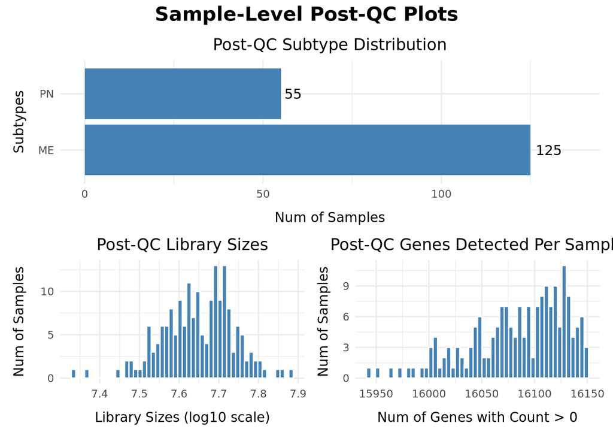

```r
#| fig-width: 10   # canvas width
#| fig-height: 15  # canvas height


sample_level_post_qc_plots <-
(post_subtype_plot) /
(post_libsize_plot | post_genedet_plot) +
plot_annotation(
  title = "Sample-Level Post-QC Plots",
  theme = theme(
            plot.title = element_text(
              hjust = 0.5,
              size = 16,
              face = "bold"
            )
          )
)

sample_level_post_qc_plots
```

#### 5.2.2. Combine Gene-Level Post-QC Plots

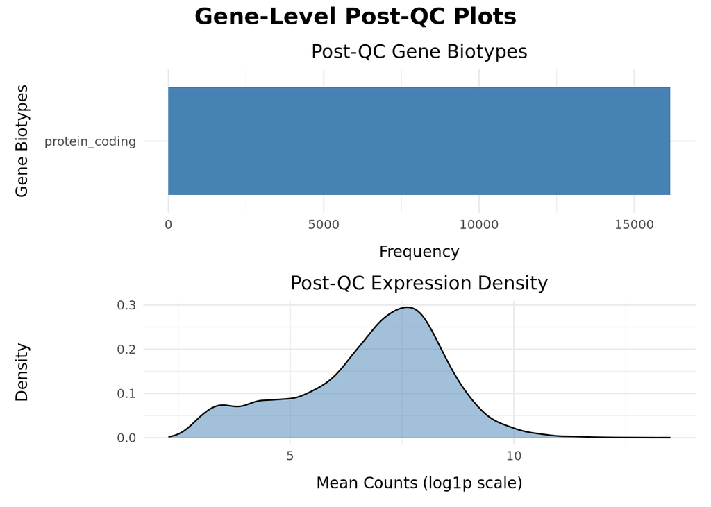

```r
#| fig-width: 10   # canvas width
#| fig-height: 15  # canvas height


gene_level_post_qc_plots <-
(post_biotype_plot) /
(post_exprdens_plot) +
plot_annotation(
  title = "Gene-Level Post-QC Plots",
  theme = theme(
            plot.title = element_text(
              hjust = 0.5,
              size = 16,
              face = "bold"
            )
          )
)

gene_level_post_qc_plots
```

## 6. Save Outputs

### 6.1. Save Filtered Data

#### 6.1.1. Save Filtered Counts Matrix

```r
saveRDS(raw_counts_matrix, "../01_data/02_processed/04_filtered_counts_matrix.rds")
cat("Saved: 04_filtered_counts_matrix.rds\n")
```

```
Saved: 04_filtered_counts_matrix.rds
```

```r
cat("Dimensions:", nrow(raw_counts_matrix), "genes x", ncol(raw_counts_matrix), "samples\n")
```

```
Dimensions: 16164 genes x 180 samples
```

#### 6.1.2. Save Filtered Tumor Subtype Information

```r
saveRDS(tumor_subtype_info, "../01_data/02_processed/05_filtered_tumor_subtype_info.rds")
cat("Saved: 05_filtered_tumor_subtype_info.rds\n")
```

```
Saved: 05_filtered_tumor_subtype_info.rds
```

```r
cat("Samples remaining:", nrow(tumor_subtype_info), "\n")
```

```
Samples remaining: 180
```

#### 6.1.3. Save Filtered Gene Metadata

```r
saveRDS(gene_metadata, "../01_data/02_processed/06_filtered_gene_metadata.rds")
cat("Saved: 06_filtered_gene_metadata.rds\n")
```

```
Saved: 06_filtered_gene_metadata.rds
```

```r
cat("Genes remaining:", nrow(gene_metadata), "\n")
```

```
Genes remaining: 16164
```

### 6.2. Save Combined QC Plots

```r
# sample-level pre-qc plots
ggsave(
  "../03_figures/03_qc/01_sample_level_pre_qc_plots.png",
  plot = sample_level_pre_qc_plots,
  width = 10,
  height = 15,
  dpi = 300
)


# gene-level pre-qc plots
ggsave(
  "../03_figures/03_qc/02_gene_level_pre_qc_plots.png",
  plot = gene_level_pre_qc_plots,
  width = 10,
  height = 15,
  dpi = 300
)


# sample-level post-qc plots
ggsave(
  "../03_figures/03_qc/03_sample_level_post_qc_plots.png",
  plot = sample_level_post_qc_plots,
  width = 10,
  height = 15,
  dpi = 300
)


# gene-level post-qc plots
ggsave(
  "../03_figures/03_qc/04_gene_level_post_qc_plots.png",
  plot = gene_level_post_qc_plots,
  width = 10,
  height = 15,
  dpi = 300
)


cat("Saved 4 QC plot files\n")
```

```
Saved 4 QC plot files
```

## 7. Perform Sanity Checks

```r
# filtered data
filtered_counts_exists   <- file.exists("../01_data/02_processed/04_filtered_counts_matrix.rds")
filtered_subtype_exists  <- file.exists("../01_data/02_processed/05_filtered_tumor_subtype_info.rds")
filtered_gene_exists     <- file.exists("../01_data/02_processed/06_filtered_gene_metadata.rds")



# combined qc plots
sample_level_pre_qc_plots_exists   <- file.exists("../03_figures/03_qc/01_sample_level_pre_qc_plots.png")
gene_level_pre_qc_plots_exists     <- file.exists("../03_figures/03_qc/02_gene_level_pre_qc_plots.png")

sample_level_post_qc_plots_exists  <- file.exists("../03_figures/03_qc/03_sample_level_post_qc_plots.png")
gene_level_post_qc_plots_exists    <- file.exists("../03_figures/03_qc/04_gene_level_post_qc_plots.png")





# print
# filtered data
cat("Filtered counts matrix saved:      ", ifelse(filtered_counts_exists,  "✓", "✗"), "\n")
```

```
Filtered counts matrix saved:       ✓
```

```r
cat("Filtered tumor subtype info saved: ", ifelse(filtered_subtype_exists, "✓", "✗"), "\n")
```

```
Filtered tumor subtype info saved:  ✓
```

```r
cat("Filtered gene metadata saved:      ", ifelse(filtered_gene_exists,    "✓", "✗"), "\n")
```

```
Filtered gene metadata saved:       ✓
```

```r
# combined qc plots
cat("\nPre-QC sample level plot saved:    ", ifelse(sample_level_pre_qc_plots_exists,  "✓", "✗"), "\n")
```

```
Pre-QC sample level plot saved:     ✓
```

```r
cat("Pre-QC gene level plot saved:      ", ifelse(gene_level_pre_qc_plots_exists,    "✓", "✗"), "\n")
```

```
Pre-QC gene level plot saved:       ✓
```

```r
cat("Post-QC sample level plot saved:   ", ifelse(sample_level_post_qc_plots_exists, "✓", "✗"), "\n")
```

```
Post-QC sample level plot saved:    ✓
```

```r
cat("Post-QC gene level plot saved:     ", ifelse(gene_level_post_qc_plots_exists,   "✓", "✗"), "\n")
```

```
Post-QC gene level plot saved:      ✓
```

```r
# check for errors
if (all(filtered_counts_exists, filtered_subtype_exists, filtered_gene_exists,
        sample_level_pre_qc_plots_exists, gene_level_pre_qc_plots_exists,
        sample_level_post_qc_plots_exists, gene_level_post_qc_plots_exists)) {
  cat("\nNotebook 03 complete — all outputs verified\n")
} else {
  cat("\nWARNING: One or more outputs missing\n")
}
```

```
Notebook 03 complete — all outputs verified
```